# Homework Assignment 1

Cesar Venegas

Assigned: Oct 24, 2020, Due Sun Nov 01, 2020 11:59PM

## HW-1 Instructions

> Our class emphasizes clear communication of data analysis results to non-technical audiences. I expect your HTML output documents to be readable and well formatted. I expect you to put ample comments in your R code to make the code understandable. Along with accuracy of results, I am looking for quality of presentation as well. This homework is due by **11:59PM on Nov 01st**. To complete this assignment, follow these steps:
1. Create a new RStudio Project for this HW. Sync the project directory with a GitHub Repository (see instructions on Canvas on how to do that).
2. Download the `HW1.Rmd` file from Canvas. Save the file in the RStudio Project Directory.
3. Open `HW1.Rmd` in RStudio. Replace the “Your Name Here” text in the `author:` field with your name.
4. Supply your solutions to the homework by editing `HW1.Rmd`.
5. Run your code in the Console and Knit HTML frequently to check for errors.
6. You may find it easier to solve a problem by interacting only with the Console at first.
7. When you have completed the homework please check that your knits correctly when you click `Knit HTML`.
8. “Push” all your local changes to the GitHub Repo for the project.
9. Submit your RMD file, the HTML output and a link to your GitHub Repo on Canvas.

## Data frame basics

We will continue working with the nycflights dataset we looked at in class. **Please be sure to keep the data file in the same directory as the RMD file - your project directory.**

First - make sure that you are reading the data correctly and doing all the data cleaning steps that we did in class. Feel free to go beyond our class work in cleaning the data if you feel the need.

## Reading the data

```r
nyc <- read.csv(file = "nycflights.csv")

nyc$X <- NULL

nyc$flight <- as.factor(nyc$flight)
nyc$origin <- as.factor(nyc$origin)
nyc$dest <- as.factor(nyc$dest)
nyc$tailnum <- as.factor(nyc$tailnum)
nyc$month <- as.factor(nyc$month)
nyc$carrier <- as.factor(nyc$carrier)
# Quick exploration of the data

str(nyc)
```

```
## 'data.frame':    336776 obs. of  19 variables:
##  $ year          : int  2013 2013 2013 2013 2013 2013 2013 2013 2013 2013 ...
##  $ month         : Factor w/ 12 levels "1","2","3","4",..: 1 1 1 1 1 1 1 1 1 1 ...
##  $ day           : int  1 1 1 1 1 1 1 1 1 1 ...
##  $ dep_time      : int  517 533 542 544 554 554 555 557 557 558 ...
##  $ sched_dep_time: int  515 529 540 545 600 558 600 600 600 600 ...
##  $ dep_delay     : int  2 4 2 -1 -6 -4 -5 -3 -3 -2 ...
##  $ arr_time      : int  830 850 923 1004 812 740 913 709 838 753 ...
##  $ sched_arr_time: int  819 830 850 1022 837 728 854 723 846 745 ...
##  $ arr_delay     : int  11 20 33 -18 -25 12 19 -14 -8 8 ...
##  $ carrier       : Factor w/ 16 levels "9E","AA","AS",..: 12 12 2 4 5 12 4 6 4 2 ...
##  $ flight        : Factor w/ 3844 levels "1","2","3","4",..: 1382 1545 1042 677 425 1527 469 3700 69 266 ...
##  $ tailnum       : Factor w/ 4043 levels "D942DN","N0EGMQ",..: 180 524 2401 3204 2661 1142 1829 3300 2207 1178 ...
##  $ origin        : Factor w/ 3 levels "EWR","JFK","LGA": 1 3 2 2 3 1 1 3 2 3 ...
##  $ dest          : Factor w/ 105 levels "ABQ","ACK","ALB",..: 44 44 59 13 5 70 36 43 55 70 ...
##  $ air_time      : int  227 227 160 183 116 150 158 53 140 138 ...
##  $ distance      : int  1400 1416 1089 1576 762 719 1065 229 944 733 ...
##  $ hour          : int  5 5 5 5 6 5 6 6 6 6 ...
##  $ minute        : int  15 29 40 45 0 58 0 0 0 0 ...
##  $ time_hour     : chr  "2013-01-01 05:00:00" "2013-01-01 05:00:00" "2013-01-01 05:00:00" "2013-01-01 05:00:00" ...
```

```r
summary(nyc)
```

```
##       year          month             day           dep_time    sched_dep_time
##  Min.   :2013   7      : 29425   Min.   : 1.00   Min.   :   1   Min.   : 106
##  1st Qu.:2013   8      : 29327   1st Qu.: 8.00   1st Qu.: 907   1st Qu.: 906
##  Median :2013   10     : 28889   Median :16.00   Median :1401   Median :1359
##  Mean   :2013   3      : 28834   Mean   :15.71   Mean   :1349   Mean   :1344
##  3rd Qu.:2013   5      : 28796   3rd Qu.:23.00   3rd Qu.:1744   3rd Qu.:1729
##  Max.   :2013   4      : 28330   Max.   :31.00   Max.   :2400   Max.   :2359
##                 (Other):163175                   NA's   :8255
##    dep_delay          arr_time    sched_arr_time   arr_delay
##  Min.   : -43.00   Min.   :   1   Min.   :   1   Min.   : -86.000
##  1st Qu.:  -5.00   1st Qu.:1104   1st Qu.:1124   1st Qu.: -17.000
##  Median :  -2.00   Median :1535   Median :1556   Median :  -5.000
##  Mean   :  12.64   Mean   :1502   Mean   :1536   Mean   :   6.895
##  3rd Qu.:  11.00   3rd Qu.:1940   3rd Qu.:1945   3rd Qu.:  14.000
##  Max.   :1301.00   Max.   :2400   Max.   :2359   Max.   :1272.000
##  NA's   :8255      NA's   :8713                  NA's   :9430
##     carrier          flight          tailnum       origin
##  UA     :58665   15     :   968   N725MQ :   575   EWR:120835
##  B6     :54635   27     :   898   N722MQ :   513   JFK:111279
##  EV     :54173   181    :   882   N723MQ :   507   LGA:104662
##  DL     :48110   301    :   871   N711MQ :   486
##  AA     :32729   161    :   786   N713MQ :   483
##  MQ     :26397   695    :   782   (Other):331700
##  (Other):62067   (Other):331589   NA's   :  2512
##       dest           air_time        distance         hour
##  ORD    : 17283   Min.   : 20.0   Min.   :  17   Min.   : 1.00
##  ATL    : 17215   1st Qu.: 82.0   1st Qu.: 502   1st Qu.: 9.00
##  LAX    : 16174   Median :129.0   Median : 872   Median :13.00
##  BOS    : 15508   Mean   :150.7   Mean   :1040   Mean   :13.18
##  MCO    : 14082   3rd Qu.:192.0   3rd Qu.:1389   3rd Qu.:17.00
##  CLT    : 14064   Max.   :695.0   Max.   :4983   Max.   :23.00
##  (Other):242450   NA's   :9430
##      minute       time_hour
##  Min.   : 0.00   Length:336776
##  1st Qu.: 8.00   Class :character
##  Median :29.00   Mode  :character
##  Mean   :26.23
##  3rd Qu.:44.00
##  Max.   :59.00
##
```

I now would like you to answer the following - all in their own separate R code blocks.

### Data Exploration

Let’s first do some simple exploration of this data.

- How many airlines are there? (Hint: `levels` and `length` can be useful here)

```r
#How many airlines are there?
length(levels(nyc$carrier))
```

```
## [1] 16
```

```r
## How many flights there were by the airline with code `OO`? (Hint: `nrow` can be useful here along with logical indexing)

OOF <- nyc[nyc$carrier == "OO", ]
nrow(OOF)
```

```
## [1] 32
```

```r
## How long is the shortest flight out of any NYC airport? (Hint: `min` can be useful, remember to handle `NA` values)


min(nyc$distance, na.rm = TRUE)
```

```
## [1] 17
```

```r
## How many flights where there by United Airlines (code: UA) on Jan 12th 2013?



UAF <- nyc[nyc$carrier == "UA" & nyc$month == 1 & nyc$day == 12 & nyc$year == 2013,]
nrow(UAF)
```

```
## [1] 112
```

### Arrival Delay

Lets focus on Arrival Delay.

```r
#What was the average arrival delay for all airports and all airlines combined in Jan 2013

JAN <- nyc[nyc$month == 1, ]
mean(JAN$arr_delay, na.rm = TRUE)
```

```
## [1] 6.129972
```

```r
##  Whats was the median arrival delay for all airports and all airlines combined in Jan 2013?

median(JAN$arr_delay, na.rm = TRUE)
```

```
## [1] -3
```

Based on your answers to the two questions above, what can you say about the distribution of arrival delays? Provide your answer in a text paragraph form.

## we can say that the distribution of arrival delays is has less cases with positive arrival delays but with a higher dispersion. Thus, those fewer cases make the mean positive but the median negative.

### Airline Performance

Lets see if all airlines are equally terrible as far as flight arrival delays are concerned. For this question you will have to make sure that airline column is coded as a factor.

```r
#Calculate average arrival delays by airline (Hint: look up the command `tapply`)
delay_AIR<- tapply(nyc$arr_delay, nyc$carrier, mean, na.rm = TRUE)
delay_AIR
```

```
##         9E         AA         AS         B6         DL         EV         F9
##  7.3796692  0.3642909 -9.9308886  9.4579733  1.6443409 15.7964311 21.9207048
##         FL         HA         MQ         OO         UA         US         VX
## 20.1159055 -6.9152047 10.7747334 11.9310345  3.5580111  2.1295951  1.7644644
##         WN         YV
##  9.6491199 15.5569853
```

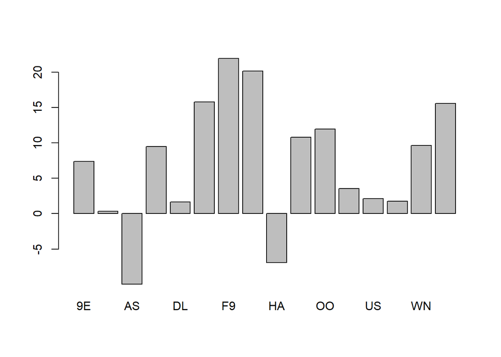

```r
#Draw a Bar Plot of Average Arrival Delays for all the Airlines (Hint: command for making a Bar Plot is simply `barplot`)
barplot(delay_AIR)
```

- Which airline has the highest average arrival delay? Which airline has the smallest average arrival delay? Are there airlines that actually have negative average delay? Provide answer to this question in a text paragraph form using **inline R code**.

```r
# F9 Airline has the highest average arrival delay. AS airline has the smallest average delay being negative.
# Yes, two airlines have negative average delay AS and HA airline
```

### Air Gain

Create a new column named airgain such that airgain = (departure delay - arrival delay) : this is the amount of delay a flight made up while in air.

```r
## Air Gain

#Creating airgain column:
nyc$AG <- nyc$dep_delay - nyc$arr_delay
summary(nyc$AG)
```

```
##    Min. 1st Qu.  Median    Mean 3rd Qu.    Max.    NA's
## -196.00   -3.00    7.00    5.66   17.00  109.00    9430
```

```r
#Average airgain by airline:
airgain_AIR <- tapply(nyc$AG, nyc$carrier, mean, na.rm = TRUE)
airgain_AIR
```

```
##         9E         AA         AS         B6         DL         EV         F9
##  9.0599052  8.2048393 15.7616361  3.5095746  7.5796089  4.0424982 -1.7195301
##         FL         HA         MQ         OO         UA         US         VX
## -1.5099213 11.8157895 -0.3293526  0.6551724  8.4588972  1.6150976 10.9921814
##         WN         YV
##  8.0125374  3.3419118
```

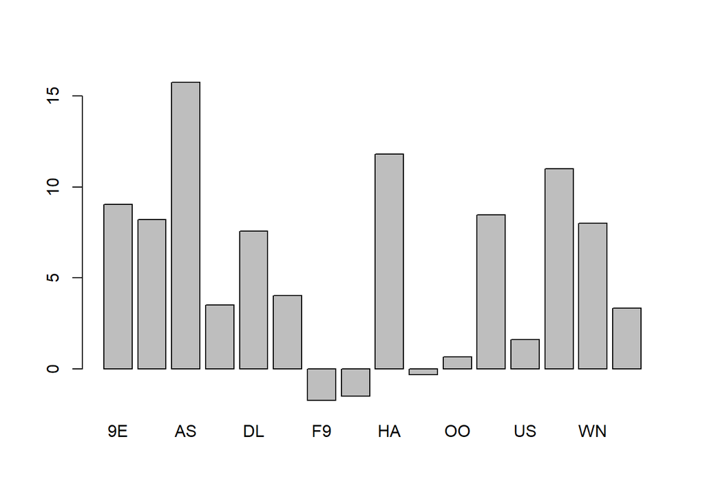

```r
#Visualization
barplot(airgain_AIR)
```

1. Explore airgain data - calculate suitable descriptive statistics and appropriate graphics to better understand this data. This part is open ended - you do what you feel works best for you.
2. Answer the questions:
- do airlines actually gain any time when in air on average?
- Calculate average airgain for different airlines - which airlines do a better job, which do a worse job?

### Merging Data Frames

> This section and the next is new compared to the class exercise. As you had an opportunity to work together in your breakout rooms for previous questions, this and the next section will carry a higher weight in grading for this HW.

You can get detailed information about the physical planes in our dataset in this file: `planes.csv`. Download and save this file in your project directory.

1. Read the `planes.csv` file using `read.csv` command. Do any data cleaning necessary.

```r
planes <- read.csv(file = "planes.csv")
planes$tailnum <- as.factor(planes$tailnum)


str(planes)
```

```
## 'data.frame':    3322 obs. of  10 variables:
##  $ X           : int  1 2 3 4 5 6 7 8 9 10 ...
##  $ tailnum     : Factor w/ 3322 levels "N10156","N102UW",..: 1 2 3 4 5 6 7 8 9 10 ...
##  $ year        : int  2004 1998 1999 1999 2002 1999 1999 1999 1999 1999 ...
##  $ type        : chr  "Fixed wing multi engine" "Fixed wing multi engine" "Fixed wing multi engine" "Fixed wing multi engine" ...
##  $ manufacturer: chr  "EMBRAER" "AIRBUS INDUSTRIE" "AIRBUS INDUSTRIE" "AIRBUS INDUSTRIE" ...
##  $ model       : chr  "EMB-145XR" "A320-214" "A320-214" "A320-214" ...
##  $ engines     : int  2 2 2 2 2 2 2 2 2 2 ...
##  $ seats       : int  55 182 182 182 55 182 182 182 182 182 ...
##  $ speed       : int  NA NA NA NA NA NA NA NA NA NA ...
##  $ engine      : chr  "Turbo-fan" "Turbo-fan" "Turbo-fan" "Turbo-fan" ...
```

```r
summary(planes)
```

```
##        X             tailnum          year          type
##  Min.   :   1.0   N10156 :   1   Min.   :1956   Length:3322
##  1st Qu.: 831.2   N102UW :   1   1st Qu.:1997   Class :character
##  Median :1661.5   N103US :   1   Median :2001   Mode  :character
##  Mean   :1661.5   N104UW :   1   Mean   :2000
##  3rd Qu.:2491.8   N10575 :   1   3rd Qu.:2005
##  Max.   :3322.0   N105UW :   1   Max.   :2013
##                   (Other):3316   NA's   :70
##  manufacturer          model              engines          seats
##  Length:3322        Length:3322        Min.   :1.000   Min.   :  2.0
##  Class :character   Class :character   1st Qu.:2.000   1st Qu.:140.0
##  Mode  :character   Mode  :character   Median :2.000   Median :149.0
##                                        Mean   :1.995   Mean   :154.3
##                                        3rd Qu.:2.000   3rd Qu.:182.0
##                                        Max.   :4.000   Max.   :450.0
##
##      speed          engine
##  Min.   : 90.0   Length:3322
##  1st Qu.:107.5   Class :character
##  Median :162.0   Mode  :character
##  Mean   :236.8
##  3rd Qu.:432.0
##  Max.   :432.0
##  NA's   :3299
```

2. Merge the flights data and the planes data using the `merge` command. You should do the merge on the common column named `tailnum`. *getting this right may need some trial and error and getting some help*.

```r
# Merge data and convert some columns to factors
# SInce I am going to focus on the performance of planes by different variables, I am going to use only the rows with data in both parts NYC and Planes

Mdata <- merge(nyc, planes, by="tailnum" )

Mdata$manufacturer <- as.factor(Mdata$manufacturer)
Mdata$model <- as.factor(Mdata$model)
Mdata$engine <- as.factor(Mdata$engine)
Mdata$type <- as.factor(Mdata$type)

nrow(nyc)
```

```
## [1] 336776
```

```r
nrow(Mdata)
```

```
## [1] 284170
```

```r
str(Mdata)
```

```
## 'data.frame':    284170 obs. of  29 variables:
##  $ tailnum       : Factor w/ 4043 levels "D942DN","N0EGMQ",..: 3 3 3 3 3 3 3 3 3 3 ...
##  $ year.x        : int  2013 2013 2013 2013 2013 2013 2013 2013 2013 2013 ...
##  $ month         : Factor w/ 12 levels "1","2","3","4",..: 8 1 1 1 2 9 3 3 11 6 ...
##  $ day           : int  12 17 23 10 17 23 12 20 3 11 ...
##  $ dep_time      : int  1312 1213 746 626 NA 1008 2000 2216 1218 1911 ...
##  $ sched_dep_time: int  1317 1218 645 630 1415 1015 2000 2100 1226 1911 ...
##  $ dep_delay     : int  -5 -5 61 -4 NA -7 0 76 -8 0 ...
##  $ arr_time      : int  1528 1422 852 802 NA 1117 2234 13 1404 2124 ...
##  $ sched_arr_time: int  1528 1415 757 800 1616 1139 2245 2315 1418 2115 ...
##  $ arr_delay     : int  0 7 55 2 NA -22 -11 58 -14 9 ...
##  $ carrier       : Factor w/ 16 levels "9E","AA","AS",..: 6 6 6 6 6 6 6 6 6 6 ...
##  $ flight        : Factor w/ 3844 levels "1","2","3","4",..: 2973 3253 2916 3186 2905 2864 2881 2628 3252 3052 ...
##  $ origin        : Factor w/ 3 levels "EWR","JFK","LGA": 1 1 1 1 1 1 1 1 1 1 ...
##  $ dest          : Factor w/ 105 levels "ABQ","ACK","ALB",..: 63 24 29 76 22 11 68 89 28 54 ...
##  $ air_time      : int  171 111 47 60 NA 105 193 101 92 157 ...
##  $ distance      : int  1167 529 199 319 628 748 1325 642 533 1092 ...
##  $ hour          : int  13 12 6 6 14 10 20 21 12 19 ...
##  $ minute        : int  17 18 45 30 15 15 0 0 26 11 ...
##  $ time_hour     : chr  "2013-08-12 13:00:00" "2013-01-17 12:00:00" "2013-01-23 06:00:00" "2013-01-10 06:00:00" ...
##  $ AG            : int  -5 -12 6 -6 NA 15 11 18 6 -9 ...
##  $ X             : int  1 1 1 1 1 1 1 1 1 1 ...
##  $ year.y        : int  2004 2004 2004 2004 2004 2004 2004 2004 2004 2004 ...
##  $ type          : Factor w/ 3 levels "Fixed wing multi engine",..: 1 1 1 1 1 1 1 1 1 1 ...
##  $ manufacturer  : Factor w/ 35 levels "AGUSTA SPA","AIRBUS",..: 18 18 18 18 18 18 18 18 18 18 ...
##  $ model         : Factor w/ 127 levels "150","172E","172M",..: 108 108 108 108 108 108 108 108 108 108 ...
##  $ engines       : int  2 2 2 2 2 2 2 2 2 2 ...
##  $ seats         : int  55 55 55 55 55 55 55 55 55 55 ...
##  $ speed         : int  NA NA NA NA NA NA NA NA NA NA ...
##  $ engine        : Factor w/ 6 levels "4 Cycle","Reciprocating",..: 3 3 3 3 3 3 3 3 3 3 ...
```

```r
summary(Mdata)
```

```
##     tailnum           year.x         month             day
##  N711MQ :   486   Min.   :2013   8      : 24876   Min.   : 1.00
##  N258JB :   427   1st Qu.:2013   7      : 24795   1st Qu.: 8.00
##  N298JB :   407   Median :2013   10     : 24651   Median :16.00
##  N353JB :   404   Mean   :2013   5      : 24370   Mean   :15.71
##  N351JB :   402   3rd Qu.:2013   3      : 24244   3rd Qu.:23.00
##  N328AA :   393   Max.   :2013   4      : 23954   Max.   :31.00
##  (Other):281651                  (Other):137280
##     dep_time    sched_dep_time   dep_delay          arr_time    sched_arr_time
##  Min.   :   1   Min.   : 500   Min.   : -43.00   Min.   :   1   Min.   :   1
##  1st Qu.: 905   1st Qu.: 905   1st Qu.:  -5.00   1st Qu.:1059   1st Qu.:1119
##  Median :1358   Median :1358   Median :  -1.00   Median :1529   Median :1553
##  Mean   :1350   Mean   :1344   Mean   :  13.18   Mean   :1495   Mean   :1531
##  3rd Qu.:1752   3rd Qu.:1730   3rd Qu.:  11.00   3rd Qu.:1942   3rd Qu.:1946
##  Max.   :2400   Max.   :2359   Max.   :1301.00   Max.   :2400   Max.   :2359
##  NA's   :4199                  NA's   :4199      NA's   :4551
##    arr_delay          carrier          flight       origin
##  Min.   : -86.00   UA     :56972   15     :   964   EWR:114927
##  1st Qu.: -17.00   EV     :54173   27     :   894   JFK: 94142
##  Median :  -5.00   B6     :53805   181    :   874   LGA: 75101
##  Mean   :   7.05   DL     :48000   161    :   783
##  3rd Qu.:  14.00   US     :19837   1109   :   714
##  Max.   :1272.00   9E     :17416   1      :   697
##  NA's   :5153      (Other):33967   (Other):279244
##       dest           air_time        distance         hour
##  LAX    : 15516   Min.   : 20.0   Min.   :  80   Min.   : 5.00
##  ATL    : 14673   1st Qu.: 83.0   1st Qu.: 529   1st Qu.: 9.00
##  BOS    : 13683   Median :131.0   Median : 937   Median :13.00
##  MCO    : 13234   Mean   :153.8   Mean   :1069   Mean   :13.18
##  SFO    : 12767   3rd Qu.:197.0   3rd Qu.:1416   3rd Qu.:17.00
##  CLT    : 12299   Max.   :695.0   Max.   :4983   Max.   :23.00
##  (Other):201998   NA's   :5153
##      minute       time_hour               AG                 X
##  Min.   : 0.00   Length:284170      Min.   :-196.000   Min.   :   1
##  1st Qu.: 7.00   Class :character   1st Qu.:  -3.000   1st Qu.: 613
##  Median :29.00   Mode  :character   Median :   8.000   Median :1417
##  Mean   :26.07                      Mean   :   6.042   Mean   :1468
##  3rd Qu.:43.00                      3rd Qu.:  17.000   3rd Qu.:2292
##  Max.   :59.00                      Max.   : 109.000   Max.   :3322
##                                     NA's   :5153
```

[output cut: 9 more lines]

```
##  BOEING                       :82912   A320-232       : 45831   Min.   :1.000
##  EMBRAER                      :66068   EMB-145LR      : 28027   1st Qu.:2.000
##  AIRBUS                       :47302   ERJ 190-100 IGW: 23716   Median :2.000
##  AIRBUS INDUSTRIE             :40891   EMB-145XR      : 14051   Mean   :1.994
##  BOMBARDIER INC               :28272   737-824        : 13809   3rd Qu.:2.000
##  MCDONNELL DOUGLAS AIRCRAFT CO: 8932   CL-600-2D24    : 11807   Max.   :4.000
##  (Other)                      : 9793   (Other)        :146929
##      seats           speed                  engine
##  Min.   :  2.0   Min.   : 90.0    4 Cycle      :    48
##  1st Qu.: 55.0   1st Qu.:105.0    Reciprocating:  1774
##  Median :149.0   Median :126.0    Turbo-fan    :240915
##  Mean   :136.7   Mean   :150.8    Turbo-jet    : 40976
##  3rd Qu.:189.0   3rd Qu.:127.0    Turbo-prop   :    47
##  Max.   :450.0   Max.   :432.0    Turbo-shaft  :   410
##                  NA's   :283207
```

3. Now that you have a merged dataset, think of what interesting questions that you can ask that can be answered using the merged dataset. You are asked to pose five interesting questions and answer them. (For example: who are the top 10 manufacturers of planes that fly out of NYC airports?) **Be creative. Be bold. Ask questions that you would want to know answers to even if you were not doing this for a HW.**
1. Best Manufacturer

```r
# BASE CASE FOR ALL QUESTIONS: I AM A MANAGER FROM AN IMPORTANT AIRLINE WHO IS IN CHARGE OF BUYING NEW PLANES AND THE PERFORMANCE OF THE CURRENT ONES
# 1) What is the best Manufacturer more air gaining?

AirGain_Manufacturer<- tapply(Mdata$AG, Mdata$manufacturer, mean, na.rm = TRUE)

AirGain_Manufacturer<-sort(AirGain_Manufacturer, decreasing = TRUE, na.last = TRUE)
AirGain_Manufacturer
```

```
##         AMERICAN AIRCRAFT INC                         PIPER
##                    17.2105263                    11.2597403
##                  STEWART MACO               LEBLANC GLENN T
##                    10.2264151                    10.1388889
##            AVIAT AIRCRAFT INC                         BEECH
##                     9.5294118                     9.1956522
##                BOMBARDIER INC                FRIEDEMANN JON
##                     9.1454247                     8.8928571
##             MCDONNELL DOUGLAS                        BOEING
##                     8.7806721                     8.0598058
##                   DEHAVILLAND                      SIKORSKY
##                     8.0163934                     7.9230769
##                   PAIR MIKE E MCDONNELL DOUGLAS AIRCRAFT CO
##                     7.7600000                     6.6486425
##                          BELL                  KILDALL GARY
##                     6.5238095                     6.0784314
##               LAMBERT RICHARD              AIRBUS INDUSTRIE
##                     6.0754717                     5.8950347
## MCDONNELL DOUGLAS CORPORATION                        AIRBUS
##                     5.7113071                     5.1155257
##        ROBINSON HELICOPTER CO        AVIONS MARCEL DASSAULT
##                     4.6476868                     4.2500000
##                   LEARJET INC                    MARZ BARRY
##                     3.5789474                     3.5000000
##                       EMBRAER                 BARKER JACK L
##                     2.8167008                     2.6760000
##                       DOUGLAS                        CESSNA
##                     2.4545455                     2.3627608
##            CIRRUS DESIGN CORP                    AGUSTA SPA
##                     2.1141869                     1.8064516
##                      CANADAIR                  CANADAIR LTD
##                     1.6575067                     1.2258065
##          GULFSTREAM AEROSPACE                   JOHN G HESS
##                     1.1751055                     0.6666667
##            HURLEY JAMES LARRY
##                    -1.3750000
```

```r
max(AirGain_Manufacturer)
```

```
## [1] 17.21053
```

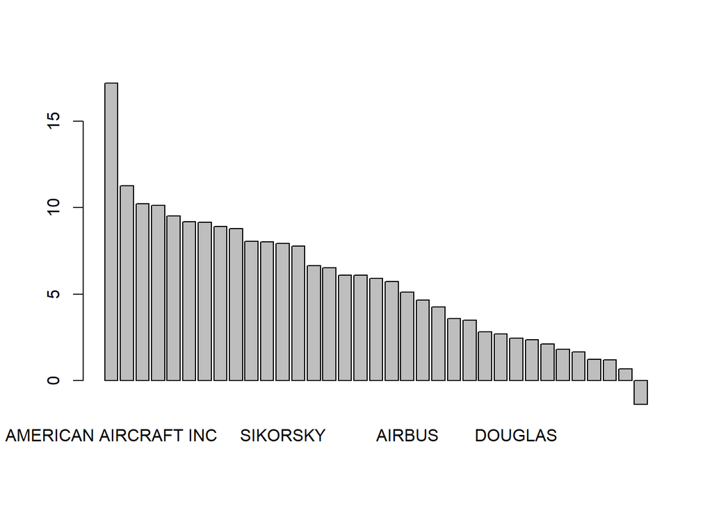

```r
barplot(AirGain_Manufacturer)
```

```r
## It look like American Aircraft inc is the top performance manufcaturer with Airgaining of 17.2.
```

```r
## 2) what is the best model based on Air Gain?

AirGain_Model<- tapply(Mdata$AG, Mdata$model, mean, na.rm = TRUE)
AirGain_Model<-sort(AirGain_Model, decreasing = TRUE, na.last = TRUE)
AirGain_Model
```

```
##            757-212            767-201            777-222            737-3A4
##         28.0000000         24.0000000         20.0000000         19.0000000
##           A330-323           A330-223          737-990ER        PA-32RT-300
##         19.0000000         16.7500000         15.9186747         15.8888889
##            737-890            737-8FH            737-7Q8            737-990
##         15.7172012         15.4375000         14.0952381         14.0000000
##         PA-32R-300            737-524          PA-28-180            747-451
##         12.9512195         12.2500000         12.1219512         12.0000000
##               E-90           A330-243            757-231            737-924
##         11.9166667         11.8157895         11.5071851         11.2228797
##          737-924ER            767-223                550        CL-600-2D24
##         11.0475971         10.9711174         10.6486486         10.5859643
##        CL-600-2C10            757-2Q8            737-832            737-7AD
##         10.5513096         10.4193122         10.2721402         10.2631579
##            757-351          FALCON XP            767-332               172M
##         10.2500000         10.2093023          9.8802206          9.6818182
##            737-705               A-1B            777-224           A319-115
##          9.5384615          9.5294118          9.5000000          9.4193548
##            737-724           A319-131     DC-9-82(MD-82)  VANS AIRCRAFT RV6
##          9.3747364          9.2698851          9.1017682          8.8928571
##            737-824           A320-214     DC-9-83(MD-83)            737-5H4
##          8.8187759          8.7863061          8.7097054          8.4848485
##               206B               172E               310Q            767-323
##          8.4500000          8.4166667          8.4090909          8.3498871
##            737-7H4            737-76Q            737-401        OTTER DHC-3
##          8.3348978          8.3043478          8.0357143          8.0163934
##              S-76A          767-424ER          PA-31-350            737-3TO
##          7.9230769          7.9015152          7.7777778          7.6000000
##           A319-132            757-2B7           A320-211            737-7BX
##          7.5121951          7.5000000          7.2085804          7.2000000
##           A319-114           A320-212            737-3Q8            757-224
##          7.0961498          6.8779741          6.7500000          6.6742795
##            767-3P6              MD-88            757-223         210-5(205)
##          6.5517241          6.5327649          6.5020161          6.4473684
##            737-8H4             65-A90          FALCON-XP               421C
##          6.3265720          6.2272727          6.0900000          6.0571429
##            757-26D            757-251            DC-9-51               G-IV
##          5.9692308          5.4562500          5.2747253          5.1666667
##              787-8        CL-600-2B19            757-33N           A320-232
##          5.0000000          4.9722311          4.9699248          4.9338425
```

[output cut: 9 more lines]

```
##          3.1739130          3.0000000          3.0000000          3.0000000
##    ERJ 190-100 IGW            EMB-145          767-432ER      ZODIAC 601HDS
##          2.8606533          2.7824427          2.7000000          2.6760000
##             DC-7BF          EMB-145LR            767-324           A321-211
##          2.4545455          2.2582059          2.2500000          2.2107178
##               SR22              A109E              CF-5D             G1159B
##          2.1141869          1.8064516          1.2258065          1.0714286
##               AT-5           A319-112            777-200              A185F
##          0.6666667         -0.1631675         -0.6470588         -0.6580087
##               172N            767-322            717-200           MD-90-30
##         -0.6797386         -0.8137931         -0.8786992         -1.0136986
##            737-76N            737-3K2            737-317            737-3G7
##         -1.6926829         -2.0000000         -2.5000000         -3.5555556
##            767-224           A340-313            777-232
##         -6.7692308        -10.1176471        -15.0000000
```

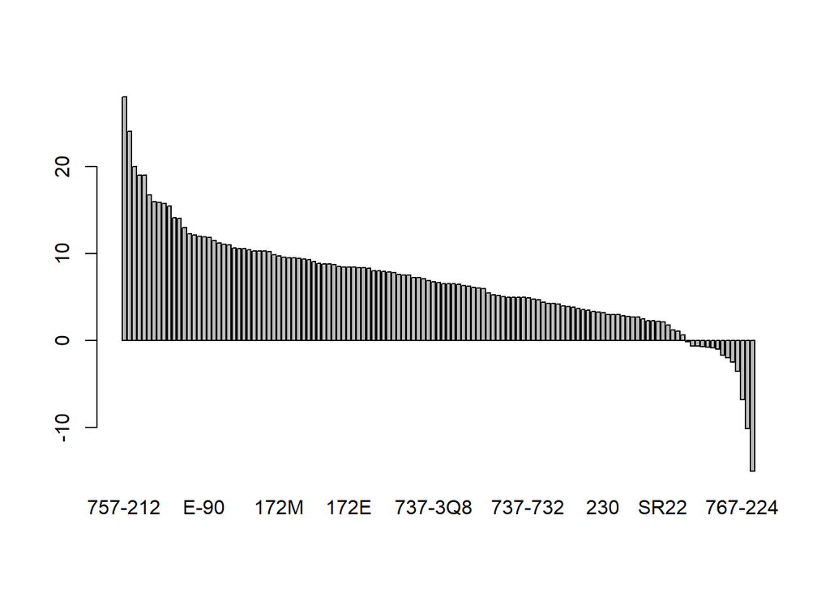

```r
barplot(AirGain_Model)
```

```r
# THe model 757-212 is the top performance in Air Gain
```

```r
## 3) According to the prvious analysis, I see some of models that are small models with low capacity. Since I work in a big airline I would like to focus on Big planes (>100 seats). Also, I noticed that Airgain is affected by the Air time so High Air time the higher the Air Gain, so I need to convert it to a ratio AirGain/ Air time in order to evaluate the performance.

# Explore Realive airgain performance in big planes in short and long distance. Any impact of Origin?

library("ggplot2")


Mdata$Trip <- ifelse(Mdata$distance>1000, "LongD", "ShortD" )
Mdata$plane_size<- ifelse(Mdata$seats>100, "Big", "Small" )
Mdata$Airgain_ratio <- Mdata$AG*100/Mdata$air_time # Ratio to understand AirGain performance in relative terms


BigPlanes <- Mdata[Mdata$plane_size =="Big",] # Filter by only big planes Seat higher than 100


AirGain_TripB <- tapply(BigPlanes$AG, list(BigPlanes$Trip), mean, na.rm = TRUE)
AirGain_TripB
```

```
##    LongD   ShortD
## 7.811035 5.371337
```

```r
Airgain_ratioB <- tapply(BigPlanes$Airgain_ratio, list(BigPlanes$Trip), mean, na.rm = TRUE)
Airgain_ratioB
```

```
##    LongD   ShortD
## 3.669353 6.731805
```

```r
AirGain_Trip_Ratio_Model <- tapply(BigPlanes$Airgain_ratio, list(BigPlanes$Trip, BigPlanes$manufacturer), mean, na.rm = TRUE)
AirGain_Trip_Ratio_Model
```

```
##        AGUSTA SPA   AIRBUS AIRBUS INDUSTRIE AMERICAN AIRCRAFT INC
## LongD          NA 2.660667         4.077444                    NA
## ShortD         NA 5.226738         6.487020                    NA
##        AVIAT AIRCRAFT INC AVIONS MARCEL DASSAULT BARKER JACK L BEECH BELL
## LongD                  NA                     NA            NA    NA   NA
## ShortD                 NA                     NA            NA    NA   NA
##          BOEING BOMBARDIER INC CANADAIR CANADAIR LTD CESSNA CIRRUS DESIGN CORP
## LongD  3.936366             NA       NA           NA     NA                 NA
## ShortD 7.901336             NA       NA           NA     NA                 NA
##        DEHAVILLAND  DOUGLAS EMBRAER FRIEDEMANN JON GULFSTREAM AEROSPACE
## LongD           NA 3.635721      NA             NA                   NA
## ShortD          NA       NA      NA             NA                   NA
##        HURLEY JAMES LARRY JOHN G HESS KILDALL GARY LAMBERT RICHARD LEARJET INC
## LongD                  NA          NA           NA              NA          NA
## ShortD                 NA          NA           NA              NA          NA
##        LEBLANC GLENN T MARZ BARRY MCDONNELL DOUGLAS
## LongD               NA         NA          5.050271
## ShortD              NA         NA          8.242085
##        MCDONNELL DOUGLAS AIRCRAFT CO MCDONNELL DOUGLAS CORPORATION PAIR MIKE E
## LongD                       5.544456                      4.589906          NA
## ShortD                      5.542245                      5.014987          NA
##        PIPER ROBINSON HELICOPTER CO SIKORSKY STEWART MACO
## LongD     NA                     NA       NA           NA
## ShortD    NA                     NA       NA           NA
```

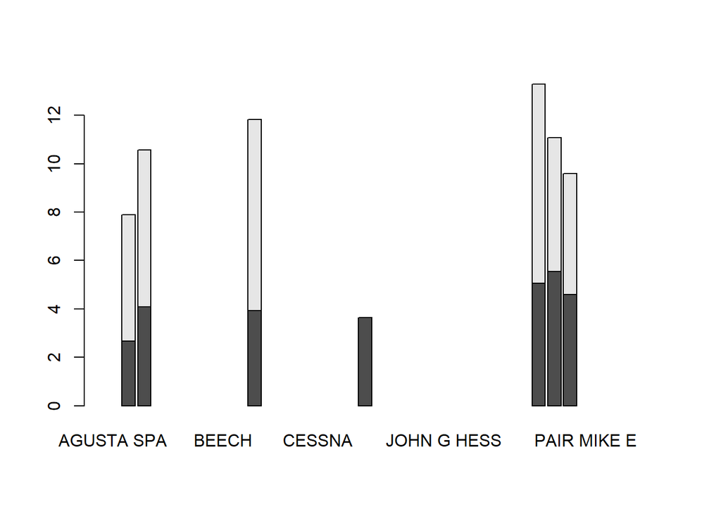

```r
barplot(AirGain_Trip_Ratio_Model)
```

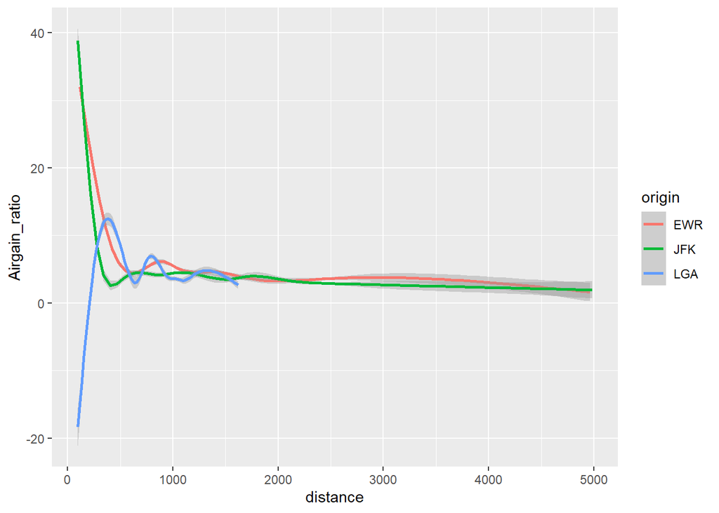

```r
RatioC <- ggplot(data=BigPlanes, aes(x=distance, y=Airgain_ratio, colour=origin))
RatioC + geom_smooth()
```

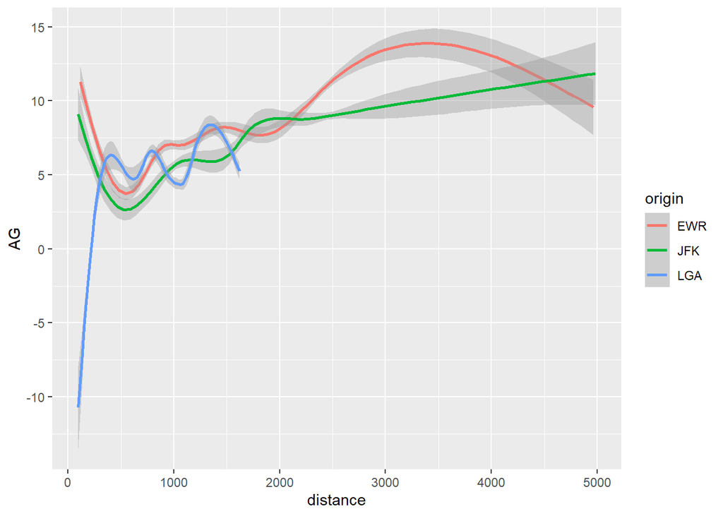

```r
RatioE <- ggplot(data=BigPlanes, aes(x=distance, y=AG, colour=origin))
RatioE + geom_smooth()
```

```r
# Overall we see that the relatiove airGain performance is better in short distance (lower than 1000 miles distance). The number of manufactuerers offering big planes is reduced. Overall the more the distance the less the relative Air Gain performance. In general we can see that Origin shows difference in relative Air Gain performance only in the short distances, after 1000 miles the relative performance slightly decreases.
```

```r
## 4) What are the Most powerful engines for big planes?



Bigplanes_Engine<- tapply(BigPlanes$AG, BigPlanes$engine, mean, na.rm = TRUE)
Bigplanes_Engine
```

```
##       4 Cycle Reciprocating     Turbo-fan     Turbo-jet    Turbo-prop
##            NA      2.454545      6.687774      7.581979            NA
##   Turbo-shaft
##            NA
```

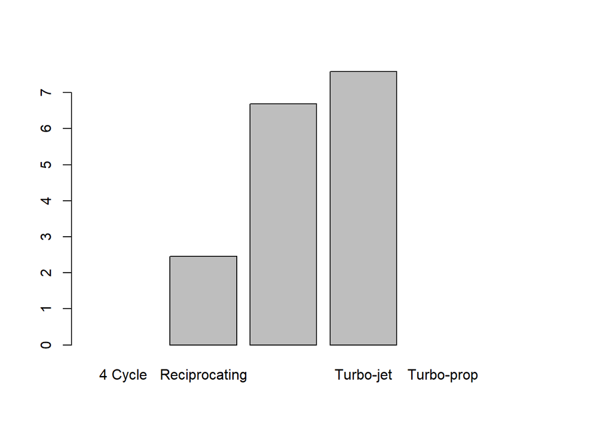

```r
barplot(Bigplanes_Engine)
```

```r
Bigplanes_EngineR<- tapply(BigPlanes$Airgain_ratio, list(BigPlanes$Trip, BigPlanes$engine), mean, na.rm = TRUE)
Bigplanes_EngineR
```

```
##        4 Cycle Reciprocating Turbo-fan Turbo-jet Turbo-prop Turbo-shaft
## LongD       NA      3.635721  3.676750  3.645561         NA          NA
## ShortD      NA            NA  6.315418  8.444860         NA          NA
```

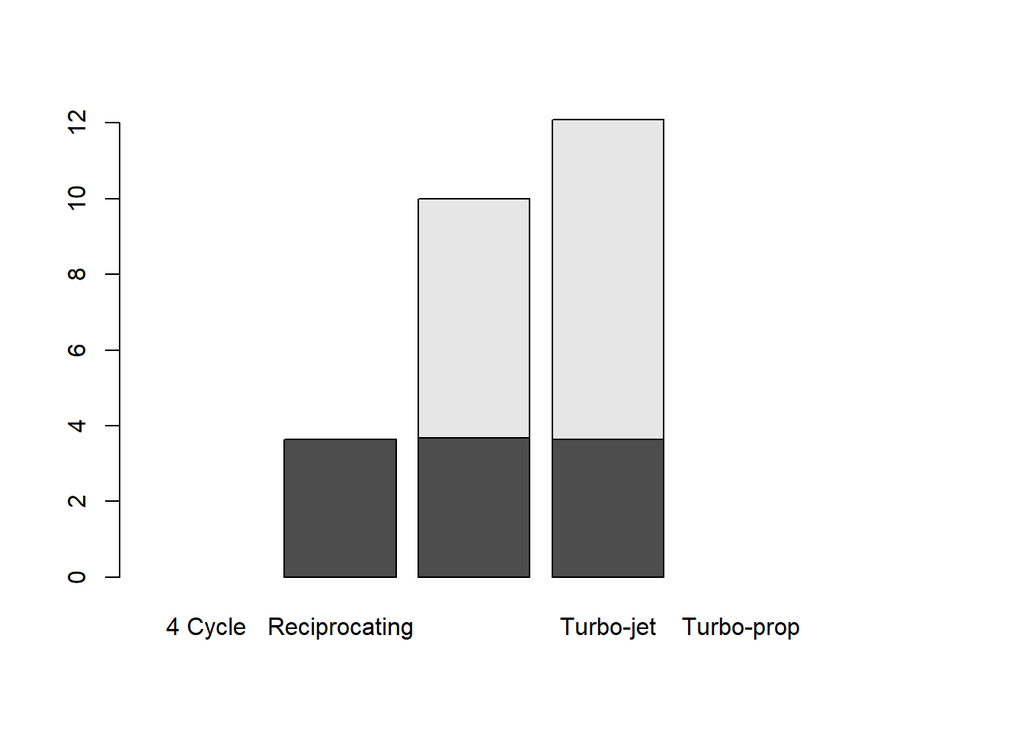

```r
barplot(Bigplanes_EngineR)
```

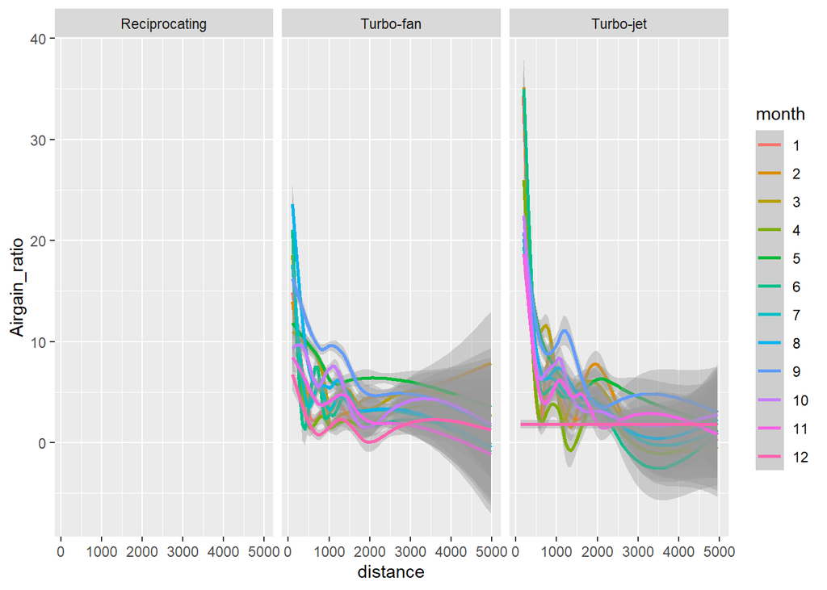

```r
EngingGraph <- ggplot(data=BigPlanes, aes(x=distance, y=Airgain_ratio, colour=month))

EngingGraph + geom_smooth() + facet_wrap(~ engine,)
```

```r
#THe most powerful engines are the Turbo Jet.
```

```r
## 5) After analysis from Q1-Q4 I have a good idea about planes performance and big planes performance. Our company is evaluating expand to routes with less traffic, meaning we are evaluationg to buy small planes. What is the best Manufacturer/motor for Small Planes?

SmallPlanes <- Mdata[Mdata$plane_size =="Small",]



SmallPlanes_Performance<- round(tapply(SmallPlanes$Airgain_ratio, list(SmallPlanes$manufacturer, SmallPlanes$engine), mean, na.rm = TRUE,), digits = 2)
SmallPlanes_Performance
```

```
##                               4 Cycle Reciprocating Turbo-fan Turbo-jet
## AGUSTA SPA                         NA            NA        NA        NA
## AIRBUS                             NA            NA      3.46        NA
## AIRBUS INDUSTRIE                   NA            NA        NA        NA
## AMERICAN AIRCRAFT INC              NA         12.65        NA        NA
## AVIAT AIRCRAFT INC                 NA          3.26        NA        NA
## AVIONS MARCEL DASSAULT             NA            NA      6.66        NA
## BARKER JACK L                      NA          2.64        NA        NA
## BEECH                              NA            NA        NA        NA
## BELL                               NA            NA        NA        NA
## BOEING                             NA            NA     -0.03        NA
## BOMBARDIER INC                     NA            NA     13.68        NA
## CANADAIR                           NA            NA      4.92        NA
## CANADAIR LTD                       NA            NA        NA      3.26
## CESSNA                           5.20          1.29      8.95        NA
## CIRRUS DESIGN CORP                 NA          1.64        NA        NA
## DEHAVILLAND                        NA          7.13        NA        NA
## DOUGLAS                            NA            NA        NA        NA
## EMBRAER                            NA            NA      5.65      6.93
## FRIEDEMANN JON                     NA          8.06        NA        NA
## GULFSTREAM AEROSPACE               NA            NA      4.67      1.89
## HURLEY JAMES LARRY                 NA          0.29        NA        NA
## JOHN G HESS                      1.41            NA        NA        NA
## KILDALL GARY                       NA          5.41        NA        NA
## LAMBERT RICHARD                    NA          4.30        NA        NA
## LEARJET INC                        NA            NA      1.15        NA
## LEBLANC GLENN T                    NA          8.24        NA        NA
## MARZ BARRY                         NA          3.40        NA        NA
## MCDONNELL DOUGLAS                  NA            NA        NA        NA
## MCDONNELL DOUGLAS AIRCRAFT CO      NA            NA        NA        NA
## MCDONNELL DOUGLAS CORPORATION      NA            NA        NA        NA
## PAIR MIKE E                        NA          3.85        NA        NA
## PIPER                              NA          8.04        NA        NA
## ROBINSON HELICOPTER CO             NA            NA        NA        NA
## SIKORSKY                           NA            NA        NA        NA
## STEWART MACO                       NA          7.49        NA        NA
##                               Turbo-prop Turbo-shaft
## AGUSTA SPA                            NA        1.64
## AIRBUS                                NA          NA
## AIRBUS INDUSTRIE                      NA          NA
```

[output cut: 17 more lines]

```
## HURLEY JAMES LARRY                    NA          NA
## JOHN G HESS                           NA          NA
## KILDALL GARY                          NA          NA
## LAMBERT RICHARD                       NA          NA
## LEARJET INC                           NA          NA
## LEBLANC GLENN T                       NA          NA
## MARZ BARRY                            NA          NA
## MCDONNELL DOUGLAS                     NA          NA
## MCDONNELL DOUGLAS AIRCRAFT CO         NA          NA
## MCDONNELL DOUGLAS CORPORATION         NA          NA
## PAIR MIKE E                           NA          NA
## PIPER                                 NA          NA
## ROBINSON HELICOPTER CO                NA        3.24
## SIKORSKY                              NA        8.45
## STEWART MACO                          NA          NA
```

```r
# In small planes, Bombardier with a Turbo-fan engine and then American Aircraft with a Reciprocating engines are the most powerful options
```

### Making Your HTML Look Nice

We want our report to be good looking, professional documents. To that end, I am asking you to do the following:

- Have a floating table of contents
- Include code folding in your output. You can find more about code folding here: https://bookdown.org/yihui/rmarkdown/html-document.html#code-folding

That’s it. Once you are done, make sure everything works and knits well and then you can push your changes to the GitHub repo and uplaod the RMD flile and the html output to Canvas.

**Have Fun!**

Sanjeev